# Reproducible Research (Course Project 1)

Christopher Johnson

November 18, 2016

Set working driectory

```r
setwd("\\\\cscphome/HOME1/CJOHNSO2/Redir-cjohnso2/Documents/RR Proj 1")
```

Load in library

```r
library(reshape2)
library(knitr)
```

Load in data

```r
if(!file.exists("getdata-projectfiles-UCI HAR Dataset.zip")) {
        temp <- tempfile()
        download.file("http://d396qusza40orc.cloudfront.net/repdata%2Fdata%2Factivity.zip",temp)
        unzip(temp)
        unlink(temp)
}
activity <- read.csv("activity.csv")
```

View Data

```r
head(activity)
```

```
##   steps       date interval
## 1    NA 2012-10-01        0
## 2    NA 2012-10-01        5
## 3    NA 2012-10-01       10
## 4    NA 2012-10-01       15
## 5    NA 2012-10-01       20
## 6    NA 2012-10-01       25
```

### What is mean total number of steps taken per day?

Sum steps by day, create Histogram.  
add a curve line for steps taken

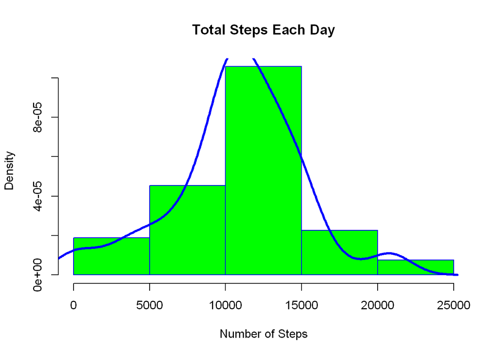

```r
meltedActivity <- melt(activity, id=c("date"), na.rm=TRUE, measure.vars="steps")
steps_by_day <- dcast(meltedActivity, date ~ variable, sum)
hist(steps_by_day$steps, main = paste("Total Steps Each Day"), col="green", border = "blue", xlab="Number of Steps", prob= TRUE)
lines(density(steps_by_day$steps),col= "blue", lwd=3)
```

Calculate and report the mean and median of the total number of steps taken per day

```r
actMean <- format(round(mean(steps_by_day$steps), 2), nsmall = 2)
actMedian <- median(steps_by_day$steps)
actMean
```

```
## [1] "10766.19"
```

```r
actMedian
```

```
## [1] 10765
```

## What is the average daily activity pattern?

*Calculate average steps for each interval for all days.* Plot the Average Number Steps per Day by Interval.

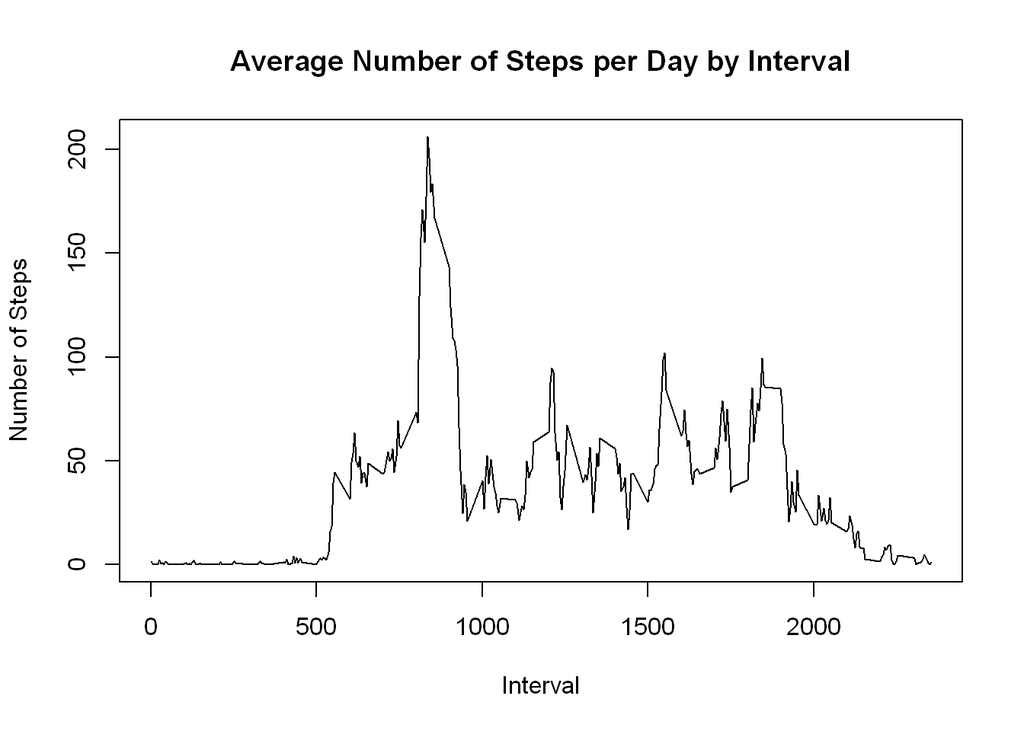

```r
steps_by_interval <- aggregate(steps ~ interval, activity, mean)

plot(steps_by_interval$interval,steps_by_interval$steps, type="l", xlab="Interval", ylab="Number of Steps",main="Average Number of Steps per Day by Interval")
```

Now which 5-minute interval, on average across all the days in the dataset, contains the maximum number of steps?

```r
Max_steps <- steps_by_interval[which.max(steps_by_interval$steps),1]
Max_steps
```

```
## [1] 835
```

### Imputing missing values

Calculate and report the total number of missing values in the dataset (i.e. the total number of rows with NAs)

```r
na_values <- activity$steps
count_of_NA <- length(which(is.na(na_values)))
count_of_NA
```

```
## [1] 2304
```

Now attempt to add data to where the NA’s value are and test if worked

```r
activity2<- activity
nas<- is.na(activity2$steps)
avg_interval<- tapply(activity2$steps, activity2$interval, mean, na.rm=TRUE, simplify = TRUE)
activity2$steps[nas] <- avg_interval[as.character(activity2$interval[nas])]
names(activity2)
```

```
## [1] "steps"    "date"     "interval"
```

check to see if missing cvalues appear

```r
sum(is.na(activity2))
```

```
## [1] 0
```

Create Histogram of new Data with out NA values Create Histogram to show difference.

[figure not shown]

```r
hist(activity2$steps, main = paste("Total Steps Each Day"), col="green", border = "blue", xlab="Number of Steps")

hist(activity$steps, main = paste("Total Steps Each Day"), col="red", border = "blue", xlab="Number of Steps", add=T)
legend("topright", c("Non NA's", "NA's"), col=c("green", "red"), lwd=10)
```

```r
meltedActivity2 <- melt(activity, id=c("date"), na.rm=TRUE, measure.vars="steps")
steps_by_day2 <- dcast(meltedActivity2, date ~ variable, sum)
newmean <- format(round(mean(steps_by_day2$steps), 2), nsmall = 2)
newmedian <- median(steps_by_day2$steps)
newmean
```

```
## [1] "10766.19"
```

```r
newmedian
```

```
## [1] 10765
```

### Are there differences in activity patterns between weekdays and weekends?

Create a plot to compare weeddays and weekends, to see if there isa difference of activity.

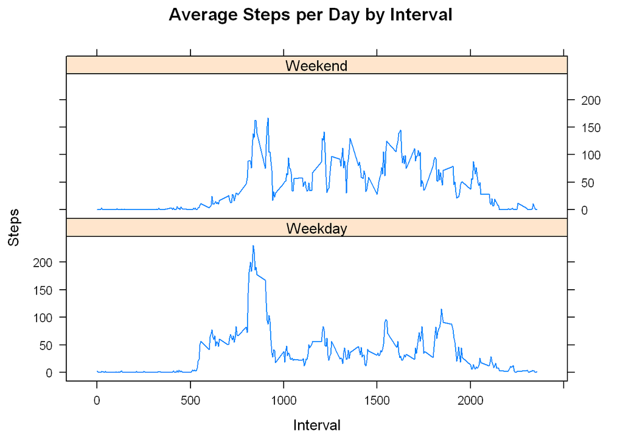

```r
weekdays <- c("Monday", "Tuesday", "Wednesday", "Thursday",
              "Friday")
activity2$dow <- as.factor(ifelse(is.element(weekdays(as.Date(activity2$date)),weekdays), "Weekday", "Weekend"))

steps_by_interval_i <- aggregate(steps ~ interval + dow, activity2, mean)

library(lattice)

xyplot(steps_by_interval_i$steps ~ steps_by_interval_i$interval|steps_by_interval_i$dow, main="Average Steps per Day by Interval",xlab="Interval", ylab="Steps",layout=c(1,2), type="l")
```